# 미다팀-IPTV 채널 시청률 데이터 동등성 검증 보고서2

Author

김가현

```r
options(encoding = "UTF-8")
Sys.setlocale("LC_CTYPE", "ko_KR.UTF-8")
```

```
[1] "ko_KR.UTF-8"
```

## 1. 분석 개요 (Overview)

본 보고서는 미다팀 데이터와 IPTV 데이터 간의 시청률 동등성을 검증하기 위한 최종 분석 결과를 기술합니다. 채널 번호 매핑 이슈를 해결하기 위해 채널명을 기준으로 1:1 매핑을 수행하였으며, 데이터 전처리, 시각화, 기초 통계 검정, 그리고 최종적으로 개별 채널 수준의 동등성 검정(Individual Equivalence Test)을 수행하여 대체 가능성을 판단합니다.

```r
if (!require("readxl")) install.packages("readxl")
if (!require("dplyr")) install.packages("dplyr")
if (!require("TOSTER")) install.packages("TOSTER")
if (!require("tolerance")) install.packages("tolerance")
```

```
tolerance package, version 3.0.0, Released 2024-04-18
This package is based upon work supported by the Chan Zuckerberg Initiative: Essential Open Source Software for Science (Grant No. 2020-255193).
```

```r
if (!require("ggplot2")) install.packages("ggplot2")
library(readxl)
library(dplyr)
library(TOSTER)
library(tolerance)
library(ggplot2)
```

## 2. 데이터 전처리 (Data Preprocessing)

### 2.1 매핑 로직 및 데이터 로드

채널 번호(ID) 기준 매핑 시 1:N 매핑 문제가 발생하여, **채널명**을 고유 식별자(Key)로 활용하여 1:1 매핑을 확정했습니다.

- **제외 대상:** IPTV 대응 데이터가 없는 채널(미다팀 원본 내 빨간색 표시), 시청 시간은 있으나 편성표 ID가 없는 채널, 검정 불가 ID 등은 분석에서 제외하였습니다.

```r
# 1. 데이터 로드
file_path <- "C:/Users/kahyu/Desktop/odata.xlsx"

df <- read_excel(file_path, sheet = "Sheet1")

df_clean <- df %>%
  select(Mida = 1, IPTV = 2) %>%
  mutate(Mida = as.numeric(Mida), IPTV = as.numeric(IPTV)) %>%
  filter(!is.na(Mida) & !is.na(IPTV))

# 2. Pairwise Difference 계산
x <- df_clean$Mida - df_clean$IPTV
cat("\n[Pairwise num] N =", length(x), "\n")
```

```
[Pairwise num] N = 254
```

## 3. 데이터 시각화 (Visualization)

데이터의 분포와 일치도를 시각적으로 확인합니다.

### 3.1 Scatterplot (산점도)

- **목적:** $Y=X$ 대각선에 데이터가 밀집해 있는지 확인하여 직관적인 일치도 판단.

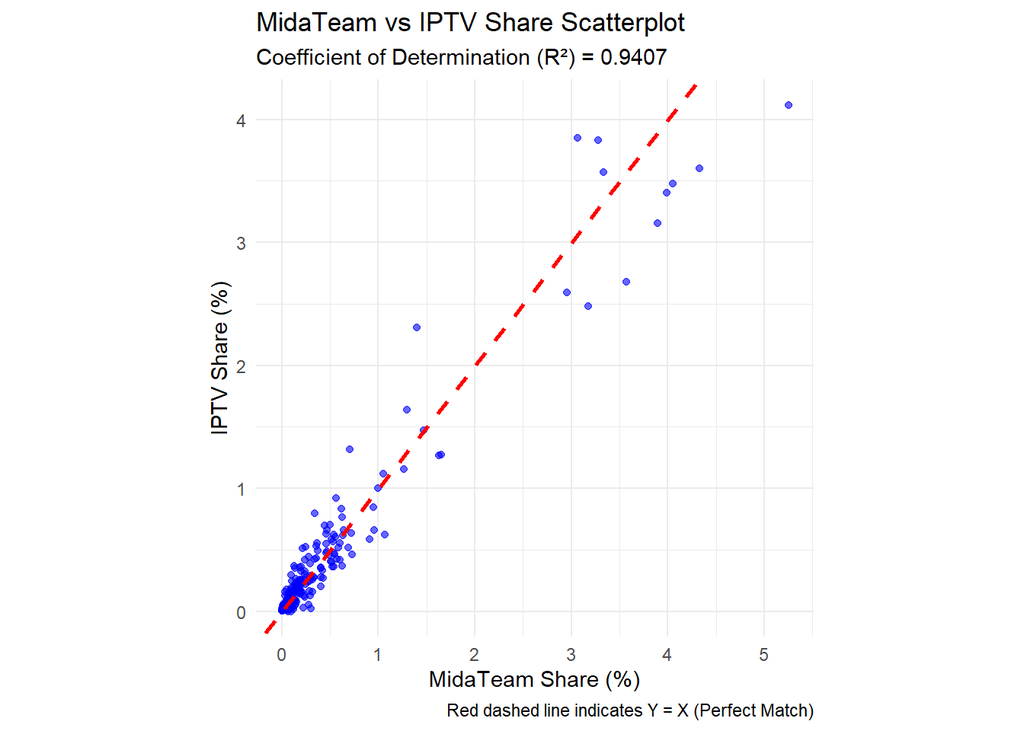

```r
# 1. 결정계수(R^2) 계산
r_sq <- cor(df_clean$Mida, df_clean$IPTV)^2

# 2. 산점도 시각화 (수정사항 반영: 정사각형 비율 및 R^2 추가)
ggplot(df_clean, aes(x = Mida, y = IPTV)) +
  geom_point(alpha = 0.6, color = "blue") +
  # 기준선 (Y=X)
  geom_abline(slope = 1, intercept = 0, color = "red", linetype = "dashed", size = 1) +
  # x, y축 범위와 비율을 동일하게 설정 (정사각형 만들기)
  coord_fixed(ratio = 1) +
  labs(title = "MidaTeam vs IPTV Share Scatterplot",
       subtitle = paste0("Coefficient of Determination (R²) = ", round(r_sq, 4)),
       x = "MidaTeam Share (%)",
       y = "IPTV Share (%)",
       caption = "Red dashed line indicates Y = X (Perfect Match)") +
  theme_minimal() +
  theme(aspect.ratio = 1)
```

### 3.2 Histogram of Differences (차이 분포)

- **목적:** 차이($D$)가 0을 중심으로 대칭적으로 분포하는지 확인.

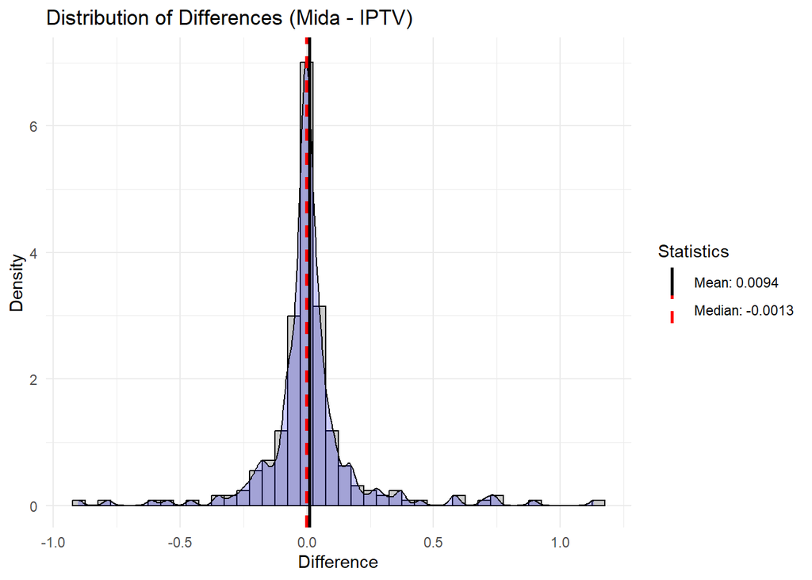

```r
df_clean$Diff <- x
mean_val <- mean(x)
median_val <- median(x)

ggplot(df_clean, aes(x = Diff)) +
  geom_histogram(aes(y = ..density..), binwidth = 0.05, fill = "gray80", color = "black") +
  geom_density(alpha = 0.2, fill = "blue") +
  geom_vline(aes(xintercept = mean_val, linetype = "Mean"), color = "black", size = 1) +
  geom_vline(aes(xintercept = median_val, linetype = "Median"), color = "red", size = 1) +
  scale_linetype_manual(name = "Statistics",
                        values = c("Mean" = "solid", "Median" = "dashed"),
                        labels = c(paste0("Mean: ", round(mean_val, 4)),
                                   paste0("Median: ", round(median_val, 4)))) +
  labs(title = "Distribution of Differences (Mida - IPTV)",
       x = "Difference", y = "Density") +
  theme_minimal()
```

## 4. 정규성 및 기초 통계 검정 (Statistical Tests)

### 4.1 Shapiro-Wilk Normality Test (Raw Data)

검정 내용: 원본 차이 데이터($D$)가 정규분포를 따르는지 확인.

가설: $H_0$: 정규분포를 따른다 vs $H_1$: 따르지 않는다.

```r
print(shapiro.test(x))
```

```
    Shapiro-Wilk normality test

data:  x
W = 0.75892, p-value < 2.2e-16
```

결과 해석: 정규성 가성을 만족하지 못한다.

### 4.2 Log-Difference Normality Check

검정 내용 및 절차: 데이터 분포의 정규성을 확인하기 위해 Shapiro-Wilk 검정을 수행합니다. 특히, 추후 진행할 TOST 분석의 가정 충족 여부를 확인하기 위해 원본 차이($D$)뿐만 아니라 로그 차이($\log(\text{Mida}) - \log(\text{IPTV})$)에 대해서도 검정을 진행했습니다.

가설 설정:

귀무가설 ($H_0$): 데이터는 정규분포를 따른다.

대립가설 ($H_1$): 데이터는 정규분포를 따르지 않는다.

```r
x_log <- log(df_clean$Mida) - log(df_clean$IPTV)
shapiro_log_result <- shapiro.test(x_log)
print(shapiro_log_result)
```

```
    Shapiro-Wilk normality test

data:  x_log
W = 0.8147, p-value < 2.2e-16
```

```r
if (shapiro_log_result$p.value < 0.05) {
  cat("해석: P-value < 0.05, H0 기각. 로그 차이 데이터는 정규성을 만족하지 않습니다.\n")
} else {
  cat("해석: P-value > 0.05, H0 채택. 로그 차이 데이터는 정규성을 만족합니다.\n")
}
```

```
해석: P-value < 0.05, H0 기각. 로그 차이 데이터는 정규성을 만족하지 않습니다.
```

결과 해석: P-value < 0.05 ($H_0$ 기각). 원본 데이터와 로그 변환 데이터 모두 정규성 가정을 만족하지 않습니다. 따라서, 이후 진행되는 동등성 분석에서는 로그 변환 없이 원본 데이터를 사용하되, 정규성에 민감하지 않은 방법(Tolerance Interval의 Howe’s Method 등)을 적용합니다.

### 4.3 Paired t-test (대응표본 t-검정)

검정 내용: 두 그룹의 평균 차이가 통계적으로 유의미한지 확인.

가설: $H_0: \mu_{diff} = 0$ vs $H_1: \mu_{diff} \neq 0$

```r
print(t.test(df_clean$Mida, df_clean$IPTV, paired = TRUE))
```

```
    Paired t-test

data:  df_clean$Mida and df_clean$IPTV
t = 0.77289, df = 253, p-value = 0.4403
alternative hypothesis: true mean difference is not equal to 0
95 percent confidence interval:
 -0.01461916  0.03350585
sample estimates:
mean difference
    0.009443343
```

검정 결과: P-value > 0.05

결과 해석: 유의수준 0.05보다 P-value가 크므로 귀무가설을 기각하지 못했습니다. 즉, 미다팀과 IPTV 시청률 간의 평균적인 차이는 통계적으로 유의미하지 않으며, 두 그룹의 평균은 유사하다고 판단됩니다.

### 4.4 Wilcoxon Signed Rank Test (윌콕슨 부호 순위 검정)

검정 내용: 정규성이 충족되지 않을 경우를 대비한 비모수적 중앙값 차이 검정.

가설: $H_0: Median_{diff} = 0$ vs $H_1: Median_{diff} \neq 0$

```r
print(wilcox.test(df_clean$Mida, df_clean$IPTV, paired = TRUE))
```

```
    Wilcoxon signed rank test with continuity correction

data:  df_clean$Mida and df_clean$IPTV
V = 16171, p-value = 0.9857
alternative hypothesis: true location shift is not equal to 0
```

검정 결과: P-value > 0.05

결과 해석: 귀무가설을 기각하지 못했습니다. 비모수적 관점에서도 두 데이터의 분포 위치(Location)에는 유의미한 차이가 없음이 재확인되었습니다.

## 5. 동등성 검정 (Equivalence Tests)

### 5.1 실질적 유의성 확인 (Practical Significance Check)

통계적인 동등성 판단에 앞서, 우리가 설정한 동등성 기준($\delta = 0.05$)이 실제 데이터 체급(Scale)에 비해 적절한지 확인합니다. 만약 대부분의 시청률 데이터 값이 0.05 이하의 매우 낮은 구간에 형성되어 있다면, 0.05의 오차는 수치상으로는 커 보일 수 있으나(데이터 대비 10배 등), 실무적으로는 모두 ’무의미한 수준의 미세 값’으로 간주할 수 있기 때문입니다.

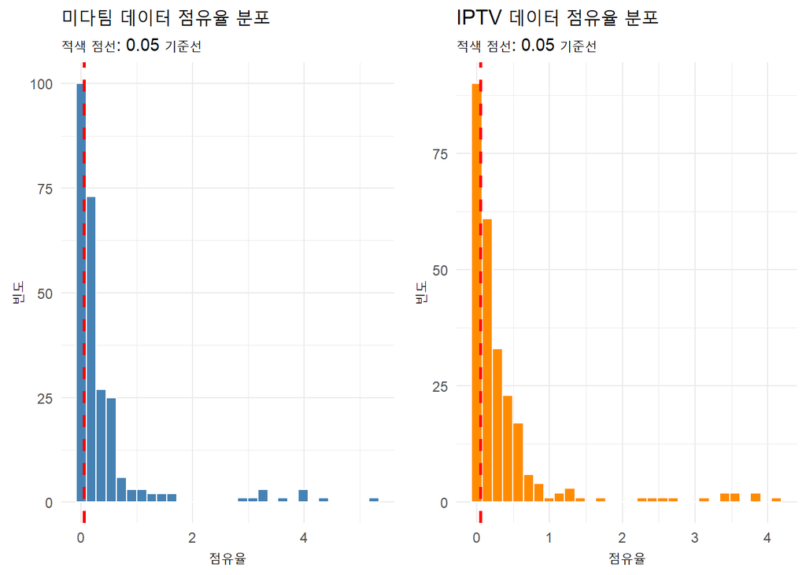

```r
# 패키지 로드 (없을 경우 설치)
if (!require("gridExtra")) install.packages("gridExtra")
library(gridExtra)

# 1. Mida 및 IPTV 원본 데이터 히스토그램 (0.05 수치 기준선 추가)
p1 <- ggplot(df_clean, aes(x = Mida)) +
  geom_histogram(fill = "steelblue", color = "white", bins = 30) +
  geom_vline(xintercept = 0.05, color = "red", linetype = "dashed", size = 1) +
  labs(title = "미다팀 데이터 점유율 분포",
       x = "점유율",
       y = "빈도",
       subtitle = "적색 점선: 0.05 기준선") +
  theme_minimal()

p2 <- ggplot(df_clean, aes(x = IPTV)) +
  geom_histogram(fill = "darkorange", color = "white", bins = 30) +
  geom_vline(xintercept = 0.05, color = "red", linetype = "dashed", size = 1) +
  labs(title = "IPTV 데이터 점유율 분포",
       x = "점유율",
       y = "빈도",
       subtitle = "적색 점선: 0.05 기준선") +
  theme_minimal()

# 두 그래프 나란히 배치
grid.arrange(p1, p2, ncol = 2)
```

### 5.2 TOST (Mean Equivalence)

검정 내용 및 절차: 두 그룹의 평균 차이가 사전에 설정한 동등성 경계($-\delta, \delta$) 내에 존재하는지 확인하는 검정입니다. 두 개의 단측 검정(Two One-Sided Tests)을 동시에 수행하여 둘 다 유의할 경우 동등하다고 판단합니다.

가설 설정:

귀무가설 ($H_{0}$): 평균 차이가 설정된 범위 밖이다 ($\mu_{diff} \le -\delta$ 또는 $\mu_{diff} \ge \delta$).

대립가설 ($H_{1}$): 평균 차이가 설정된 범위 안이다 ($-\delta < \mu_{diff} < \delta$, 동등함).

```r
delta_list <- c(0.01, 0.02, 0.0001, 0.05)
for (d in delta_list) {
  cat("\nDelta:", d, "\n")
  print(t_TOST(x = x, low_eqbound = -d, high_eqbound = d, mu = 0, plot = FALSE))
}
```

```
Delta: 0.01

One Sample t-test

The equivalence test was non-significant, t(253) = -0.046, p = 0.48
The null hypothesis test was non-significant, t(253) = 0.773, p = 0.44
NHST: don't reject null significance hypothesis that the effect is equal to zero
TOST: don't reject null equivalence hypothesis

TOST Results
                  t  df p.value
t-test      0.77289 253   0.440
TOST Lower  1.59133 253   0.056
TOST Upper -0.04556 253   0.482

Effect Sizes
           Estimate      SE              C.I. Conf. Level
Raw        0.009443 0.01222 [-0.0107, 0.0296]         0.9
Hedges's g 0.048351 0.06278 [-0.0547, 0.1513]         0.9
Note: SMD confidence intervals are an approximation. See vignette("SMD_calcs").

Delta: 0.02

One Sample t-test

The equivalence test was non-significant, t(253) = -0.86, p = 0.19
The null hypothesis test was non-significant, t(253) = 0.773, p = 0.44
NHST: don't reject null significance hypothesis that the effect is equal to zero
TOST: don't reject null equivalence hypothesis

TOST Results
                 t  df p.value
t-test      0.7729 253   0.440
TOST Lower  2.4098 253   0.008
TOST Upper -0.8640 253   0.194

Effect Sizes
           Estimate      SE              C.I. Conf. Level
Raw        0.009443 0.01222 [-0.0107, 0.0296]         0.9
Hedges's g 0.048351 0.06278 [-0.0547, 0.1513]         0.9
```

[output cut: 28 more lines]

```
The null hypothesis test was non-significant, t(253) = 0.773, p = 0.44
NHST: don't reject null significance hypothesis that the effect is equal to zero
TOST: reject null equivalence hypothesis

TOST Results
                 t  df p.value
t-test      0.7729 253    0.44
TOST Lower  4.8651 253 < 0.001
TOST Upper -3.3193 253 < 0.001

Effect Sizes
           Estimate      SE              C.I. Conf. Level
Raw        0.009443 0.01222 [-0.0107, 0.0296]         0.9
Hedges's g 0.048351 0.06278 [-0.0547, 0.1513]         0.9
Note: SMD confidence intervals are an approximation. See vignette("SMD_calcs").
```

결과 해석: $\delta=0.01, 0.02$에서는 기각 실패, $\delta=0.05$에서는 기각 성공. 평균적인 오차는 5%p 이내로 들어오지만, 1~2%p 수준의 엄격한 기준으로는 통계적으로 확실하게 동등하다고 말하기 어렵습니다. 이는 데이터 자체의 변동성(표준편차)이 존재하기 때문입니다.

### 5.3 Individual Equivalence Test (Final)

가설 설정:

1. 귀무가설 1 ($H_{10}$): $q_{1-p/2} \le L$ (상위 꼬리가 목표 하한보다 낮다) -> 기각 시 $q_{1-p/2} > L$ 성공
2. 귀무가설 2 ($H_{20}$): $q_{p/2} \ge U$ (하위 꼬리가 목표 상한보다 크다) -> 기각 시 $q_{p/2} < U$ 성공

```r
# 목표 동등성 경계 설정 (Target Bounds)
Target_L <- -0.5
Target_U <-  0.5

tol_result <- normtol.int(x = x, alpha = 0.05, P = 0.95, side = 2, method = "HE", log.norm = FALSE)
Calc_L <- tol_result[1, "2-sided.lower"]
Calc_U <- tol_result[1, "2-sided.upper"]

cat(sprintf("Calculated 95%% Tolerance Interval: [%.5f, %.5f]\n", Calc_L, Calc_U))
```

```
Calculated 95% Tolerance Interval: [-0.40336, 0.42225]
```

```r
cat(sprintf("Target Equivalence Limit         : [%.5f, %.5f]\n", Target_L, Target_U))
```

```
Target Equivalence Limit         : [-0.50000, 0.50000]
```

```r
reject_H10 <- Calc_L >= Target_L
reject_H20 <- Calc_U <= Target_U

if (reject_H10 && reject_H20) {
  cat("\nFinal Result: PASS (Individually Equivalent)\n")
  cat("   계산된 구간이 목표 범위 내에 포함되므로, 두 데이터는 개별 채널 수준에서 동등합니다.\n")
} else {
  cat("\nFinal Result: FAIL (Not Equivalent)\n")
  cat("   계산된 구간이 목표 범위를 벗어납니다.\n")
}
```

```
Final Result: PASS (Individually Equivalent)
   계산된 구간이 목표 범위 내에 포함되므로, 두 데이터는 개별 채널 수준에서 동등합니다.
```

결과 해석: 계산된 95% 허용 구간: $[-0.403, 0.422]$, 목표 동등성 경계: $[-0.5, 0.5]$. 판정: 계산된 구간이 목표 경계 내에 완전히 포함되므로, 두 귀무가설 모두 기각 ($P < 0.05$). 통계적으로 전체 채널의 95% 이상이 오차 범위 $\pm 0.42\%p$ 이내에서 일치함이 입증되었습니다. 따라서, 허용 오차 $\pm 0.5\%p$ 기준 하에서 미다팀 데이터는 IPTV 데이터와 개별 채널 수준에서 동등하며, 대체 가능합니다.

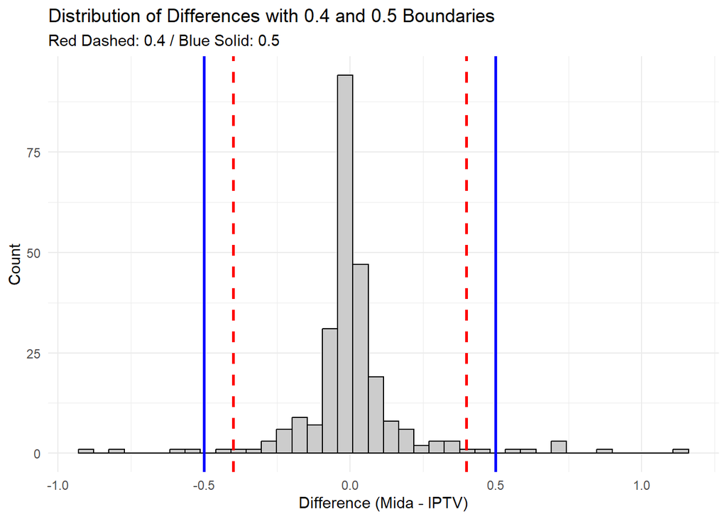

```r
# 1. 차이 데이터 준비
diff_data <- df_clean$Mida - df_clean$IPTV

# 2. 기본 히스토그램 (정사각형 설정 없이 기본값 사용)
ggplot(data.frame(x = diff_data), aes(x = x)) +
  geom_histogram(fill = "gray80", color = "black", bins = 40) +
  # 0.4 기준선 (빨간 점선)
  geom_vline(xintercept = c(-0.4, 0.4), color = "red", linetype = "dashed", size = 1) +
  # 0.5 기준선 (파란 실선)
  geom_vline(xintercept = c(-0.5, 0.5), color = "blue", size = 1) +
  labs(title = "Distribution of Differences with 0.4 and 0.5 Boundaries",
       subtitle = "Red Dashed: 0.4 / Blue Solid: 0.5",
       x = "Difference (Mida - IPTV)",
       y = "Count") +
  theme_minimal()
```

```r
# 1. 테스트할 파라미터 조합 설정
alphas <- c(0.05, 0.1)     # 95% 신뢰수준, 90% 신뢰수준
ps <- c(0.95, 0.90, 0.85)  # 포함 범위 95%, 90%, 85%
target <- 0.5              # 목표 허용 한계

# 2. 결과 저장용 데이터프레임
sensitivity_table <- data.frame()

# 3. 반복문을 통한 계산 과정 (교수님 요청사항 포함)
for (a in alphas) {
  for (p in ps) {
    # Tolerance Interval 계산
    out <- normtol.int(x = diff_data, alpha = a, P = p, side = 2, method = "HE")

    L_calc <- out[1, "2-sided.lower"] # Lower Bound
    U_calc <- out[1, "2-sided.upper"] # Upper Bound

    # 결과 행 추가
    sensitivity_table <- rbind(sensitivity_table, data.frame(
      Confidence_Level = 1 - a,
      Coverage_P = p,
      Lower_Bound = round(L_calc, 4),
      Upper_Bound = round(U_calc, 4),
      Status = ifelse(L_calc >= -target && U_calc <= target, "PASS", "FAIL")
    ))
  }
}

# 4. 결과 출력
print(sensitivity_table)
```

```
  Confidence_Level Coverage_P Lower_Bound Upper_Bound Status
1             0.95       0.95     -0.4034      0.4222   PASS
2             0.95       0.90     -0.3370      0.3559   PASS
3             0.95       0.85     -0.2937      0.3126   PASS
4             0.90       0.95     -0.3964      0.4153   PASS
5             0.90       0.90     -0.3312      0.3501   PASS
6             0.90       0.85     -0.2887      0.3075   PASS
```

- **Lower Bound (**$L_{calc}$): 하위 $(1-P)/2$ 분위수에 대한 신뢰구간의 하한값 (Lower Confidence Bound for the $(1-P)/2$ Quantile)
- **Upper Bound (**$U_{calc}$): 상위 $(1-P)/2$ 분위수에 대한 신뢰구간의 상한값 (Upper Confidence Bound for the $1-(1-P)/2$ Quantile)

**최종 결론:** 신뢰수준을 90%($\alpha=0.1$)로 낮추거나 포함 범위($P$)를 0.85까지 조정하는 등 **다양한 민감도 분석**을 수행한 결과, 모든 조건에서 산출된 구간이 목표치인 $\pm 0.5$ 이내에 존재함을 확인하였습니다. 이는 본 데이터의 동등성 결론이 매우 안정적임을 의미합니다.